# A quick tour of **qcc**

## Process capability analysis

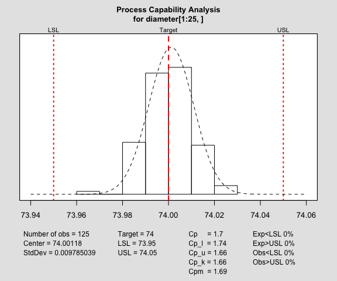

```
##
## Process Capability Analysis
##
## Call:
## process.capability(object = q1, spec.limits = c(73.95, 74.05))
##
## Number of obs = 125          Target = 74
##        Center = 74              LSL = 73.95
##        StdDev = 0.009785        USL = 74.05
##
## Capability indices:
##
##       Value   2.5%  97.5%
## Cp    1.703  1.491  1.915
## Cp_l  1.743  1.555  1.932
## Cp_u  1.663  1.483  1.844
## Cp_k  1.663  1.448  1.878
## Cpm   1.691  1.480  1.902
##
## Exp<LSL 0%    Obs<LSL 0%
## Exp>USL 0%    Obs>USL 0%
```

```r
data(pistonrings)
diameter = with(pistonrings, qcc.groups(diameter, sample))

q1 = qcc(diameter[1:25,], type="xbar", nsigmas=3, plot=FALSE)
process.capability(q1, spec.limits=c(73.95,74.05))
```

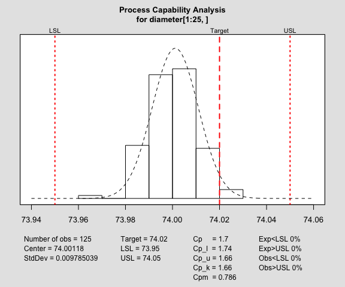

```
##
## Process Capability Analysis
##
## Call:
## process.capability(object = q1, spec.limits = c(73.95, 74.05),     target = 74.02)
##
## Number of obs = 125          Target = 74.02
##        Center = 74              LSL = 73.95
##        StdDev = 0.009785        USL = 74.05
##
## Capability indices:
##
##        Value    2.5%   97.5%
## Cp    1.7033  1.4914  1.9148
## Cp_l  1.7433  1.5548  1.9319
## Cp_u  1.6632  1.4827  1.8437
## Cp_k  1.6632  1.4481  1.8783
## Cpm   0.7856  0.6556  0.9154
##
## Exp<LSL 0%    Obs<LSL 0%
## Exp>USL 0%    Obs>USL 0%
```

```r
process.capability(q1, spec.limits=c(73.95,74.05), target=74.02)
```

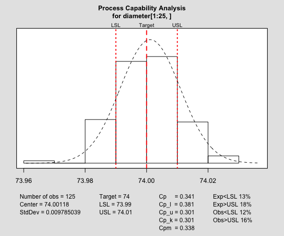

```
##
## Process Capability Analysis
##
## Call:
## process.capability(object = q1, spec.limits = c(73.99, 74.01))
##
## Number of obs = 125          Target = 74
##        Center = 74              LSL = 73.99
##        StdDev = 0.009785        USL = 74.01
##
## Capability indices:
##
##        Value    2.5%   97.5%
## Cp    0.3407  0.2983  0.3830
## Cp_l  0.3807  0.3176  0.4439
## Cp_u  0.3006  0.2424  0.3588
## Cp_k  0.3006  0.2312  0.3700
## Cpm   0.3382  0.2960  0.3804
##
## Exp<LSL 13%   Obs<LSL 12%
## Exp>USL 18%   Obs>USL 16%
```

```r
process.capability(q1, spec.limits=c(73.99,74.01))
```

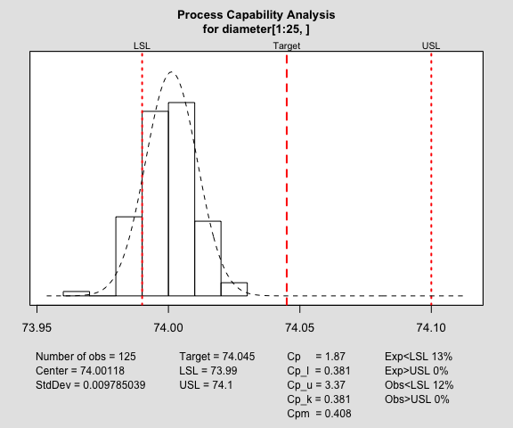

```
##
## Process Capability Analysis
##
## Call:
## process.capability(object = q1, spec.limits = c(73.99, 74.1))
##
## Number of obs = 125          Target = 74.05
##        Center = 74              LSL = 73.99
##        StdDev = 0.009785        USL = 74.1
##
## Capability indices:
##
##        Value    2.5%   97.5%
## Cp    1.8736  1.6406  2.1063
## Cp_l  0.3807  0.3176  0.4439
## Cp_u  3.3665  3.0115  3.7215
## Cp_k  0.3807  0.3055  0.4559
## Cpm   0.4083  0.3377  0.4788
##
## Exp<LSL 13%   Obs<LSL 12%
## Exp>USL 0%    Obs>USL 0%
```

```r
process.capability(q1, spec.limits = c(73.99, 74.1))
```

## Multivariate Quality Control Charts

Multivariate subgrouped data from Ryan (2000, Table 9.2) with $p = 2$ variables, $m = 20$ samples, and $n = 4$ sample size for each sample:

```r
X1 = matrix(c(72, 56, 55, 44, 97, 83, 47, 88, 57, 26, 46,
49, 71, 71, 67, 55, 49, 72, 61, 35, 84, 87, 73, 80, 26, 89, 66,
50, 47, 39, 27, 62, 63, 58, 69, 63, 51, 80, 74, 38, 79, 33, 22,
54, 48, 91, 53, 84, 41, 52, 63, 78, 82, 69, 70, 72, 55, 61, 62,
41, 49, 42, 60, 74, 58, 62, 58, 69, 46, 48, 34, 87, 55, 70, 94,
49, 76, 59, 57, 46), ncol = 4)
X2 = matrix(c(23, 14, 13, 9, 36, 30, 12, 31, 14, 7, 10,
11, 22, 21, 18, 15, 13, 22, 19, 10, 30, 31, 22, 28, 10, 35, 18,
11, 10, 11, 8, 20, 16, 19, 19, 16, 14, 28, 20, 11, 28, 8, 6,
15, 14, 36, 14, 30, 8, 35, 19, 27, 31, 17, 18, 20, 16, 18, 16,
13, 10, 9, 16, 25, 15, 18, 16, 19, 10, 30, 9, 31, 15, 20, 35,
12, 26, 17, 14, 16), ncol = 4)
X = list(X1 = X1, X2 = X2) # a list of matrices, one for each variable

q = mqcc(X, type = "T2")
```

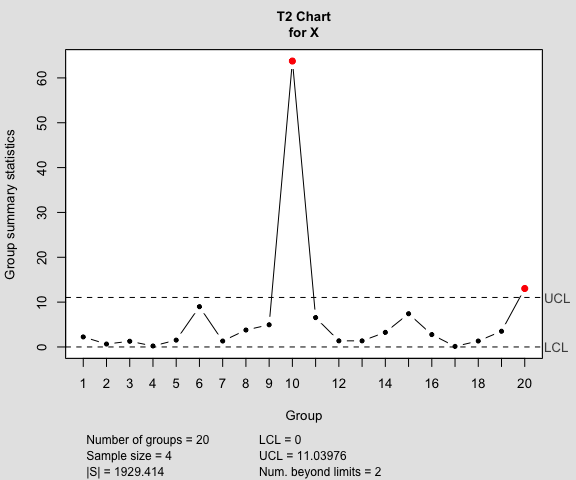

```r
summary(q)
```

```
##
## Call:
## mqcc(data = X, type = "T2")
##
## T2 chart for X
##
## Summary of group statistics:
##     Min.  1st Qu.   Median     Mean  3rd Qu.     Max.
##  0.12429  1.32496  2.50272  6.47013  5.34912 63.76042
##
## Number of variables:  2
## Number of groups:  20
## Group sample size:  4
##
## Center:
##      X1      X2
## 60.3750 18.4875
##
## Covariance matrix:
##          X1        X2
## X1 222.0333 103.11667
## X2 103.1167  56.57917
## |S|:  1929.414
##
## Control limits:
##  LCL      UCL
##    0 11.03976
```

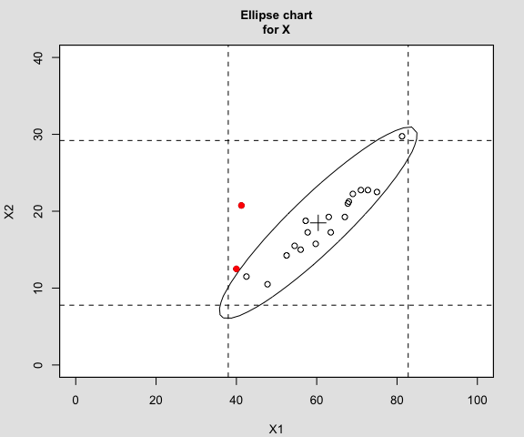

```r
ellipseChart(q)
```

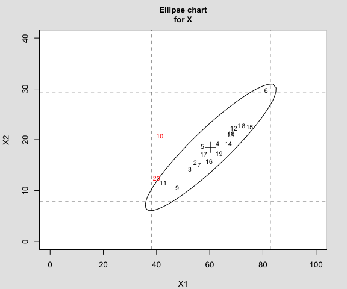

```r
ellipseChart(q, show.id = TRUE)
```

```r
q = mqcc(X, type = "T2", pred.limits = TRUE)
```

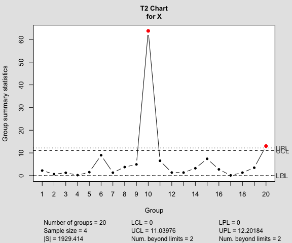

Ryan (2000) discussed Xbar-charts for single variables computed adjusting the confidence level of the $T^2$ chart:

```r
q1 = qcc(X1, type = "xbar", confidence.level = q$confidence.level^(1/2))
```

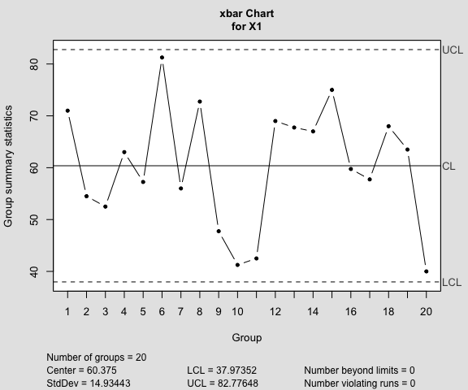

```r
summary(q1)
```

```
##
## Call:
## qcc(data = X1, type = "xbar", confidence.level = q$confidence.level^(1/2))
##
## xbar chart for X1
##
## Summary of group statistics:
##    Min. 1st Qu.  Median    Mean 3rd Qu.    Max.
##  40.000  54.000  61.375  60.375  68.250  81.250
##
## Group sample size:  4
## Number of groups:  20
## Center of group statistics:  60.375
## Standard deviation:  14.93443
##
## Control limits:
##       LCL      UCL
##  37.97352 82.77648
```

```r
q2 = qcc(X2, type = "xbar", confidence.level = q$confidence.level^(1/2))
```

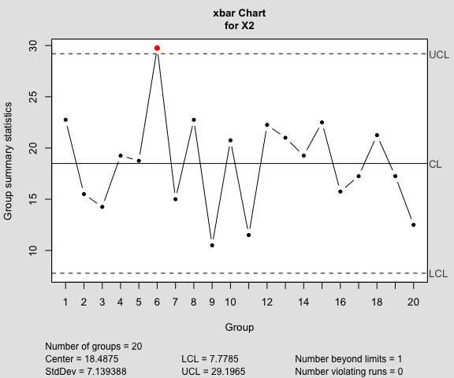

```r
summary(q2)
```

```
##
## Call:
## qcc(data = X2, type = "xbar", confidence.level = q$confidence.level^(1/2))
##
## xbar chart for X2
##
## Summary of group statistics:
##    Min. 1st Qu.  Median    Mean 3rd Qu.    Max.
## 10.5000 15.3750 19.0000 18.4875 21.5000 29.7500
##
## Group sample size:  4
## Number of groups:  20
## Center of group statistics:  18.4875
## Standard deviation:  7.139388
##
## Control limits:
##     LCL     UCL
##  7.7785 29.1965
```

Generate new “in control” data:

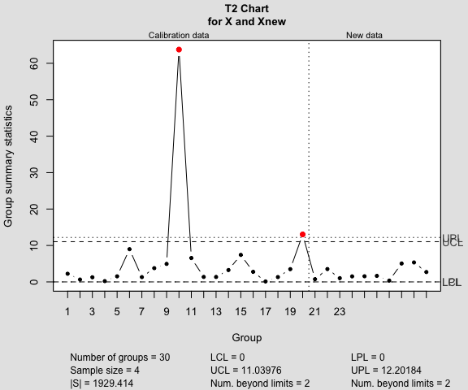

```r
Xnew = list(X1 = matrix(NA, 10, 4), X2 =  matrix(NA, 10, 4))
for(i in 1:4)
   { x = MASS::mvrnorm(10, mu = q$center, Sigma = q$cov)
     Xnew$X1[,i] = x[,1]
     Xnew$X2[,i] = x[,2]
   }
qq = mqcc(X, type = "T2", newdata = Xnew, pred.limits = TRUE)
```

```r
summary(qq)
```

```
##
## Call:
## mqcc(data = X, type = "T2", pred.limits = TRUE, newdata = Xnew)
##
## T2 chart for X
##
## Summary of group statistics:
##     Min.  1st Qu.   Median     Mean  3rd Qu.     Max.
##  0.12429  1.32496  2.50272  6.47013  5.34912 63.76042
##
## Number of variables:  2
## Number of groups:  20
## Group sample size:  4
##
## Center:
##      X1      X2
## 60.3750 18.4875
##
## Covariance matrix:
##          X1        X2
## X1 222.0333 103.11667
## X2 103.1167  56.57917
## |S|:  1929.414
##
## Summary of group statistics in Xnew:
##     Min.  1st Qu.   Median     Mean  3rd Qu.     Max.
## 0.356345 1.148565 1.602482 2.347734 3.318625 5.342685
##
## Number of groups:  10
## Group sample size:  4
##
## Control limits:
##  LCL      UCL
##    0 11.03976
##
## Prediction limits:
##  LPL      UPL
##    0 12.20184
```

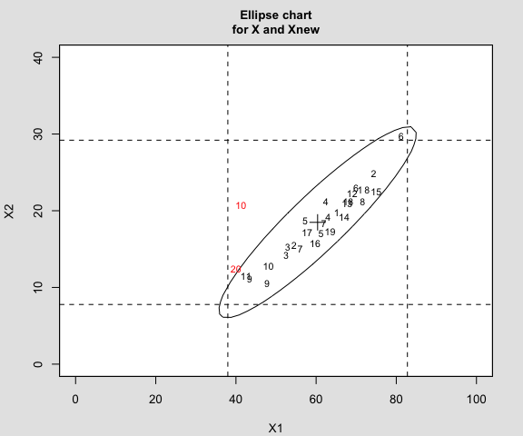

```r
ellipseChart(qq, show.id = TRUE)
```

Generate new “out of control” data:

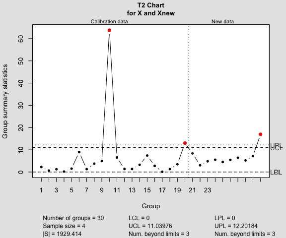

```r
Xnew = list(X1 = matrix(NA, 10, 4), X2 =  matrix(NA, 10, 4))
for(i in 1:4)
   { x = MASS::mvrnorm(10, mu = 1.2*q$center, Sigma = q$cov)
     Xnew$X1[,i] = x[,1]
     Xnew$X2[,i] = x[,2]
   }
qq = mqcc(X, type = "T2", newdata = Xnew, pred.limits = TRUE)
```

```r
summary(qq)
```

```
##
## Call:
## mqcc(data = X, type = "T2", pred.limits = TRUE, newdata = Xnew)
##
## T2 chart for X
##
## Summary of group statistics:
##     Min.  1st Qu.   Median     Mean  3rd Qu.     Max.
##  0.12429  1.32496  2.50272  6.47013  5.34912 63.76042
##
## Number of variables:  2
## Number of groups:  20
## Group sample size:  4
##
## Center:
##      X1      X2
## 60.3750 18.4875
##
## Covariance matrix:
##          X1        X2
## X1 222.0333 103.11667
## X2 103.1167  56.57917
## |S|:  1929.414
##
## Summary of group statistics in Xnew:
##      Min.   1st Qu.    Median      Mean   3rd Qu.      Max.
##  3.045001  4.935299  5.498651  6.758231  6.989239 16.962860
##
## Number of groups:  10
## Group sample size:  4
##
## Control limits:
##  LCL      UCL
##    0 11.03976
##
## Prediction limits:
##  LPL      UPL
##    0 12.20184
```

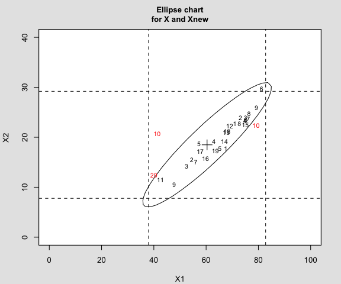

```r
ellipseChart(qq, show.id = TRUE)
```

Individual observations data:

```r
data(boiler)

q1 = mqcc(boiler, type = "T2.single", confidence.level = 0.999)
```

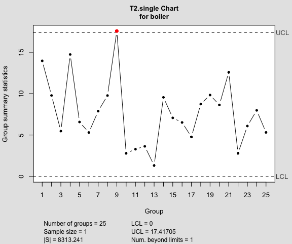

```r
summary(q1)
```

```
##
## Call:
## mqcc(data = boiler, type = "T2.single", confidence.level = 0.999)
##
## T2.single chart for boiler
##
## Summary of group statistics:
##      Min.   1st Qu.    Median      Mean   3rd Qu.      Max.
##  1.316342  5.305689  7.074224  7.680000  9.775744 17.575293
##
## Number of variables:  8
## Number of groups:  25
## Group sample size:  1
##
## Center:
##     t1     t2     t3     t4     t5     t6     t7     t8
## 525.00 513.56 538.92 521.68 503.80 512.44 478.72 477.24
##
## Covariance matrix:
##            t1        t2        t3         t4         t5         t6
## t1 54.0000000 0.9583333 20.583333 31.2916667 20.3333333 -2.2916667
## t2  0.9583333 4.8400000  2.963333  2.6866667  0.3250000  3.0766667
## t3 20.5833333 2.9633333 22.993333 10.0566667  4.9833333  2.0366667
## t4 31.2916667 2.6866667 10.056667 22.3100000 13.5583333 -2.2700000
## t5 20.3333333 0.3250000  4.983333 13.5583333 11.4166667 -1.6583333
## t6 -2.2916667 3.0766667  2.036667 -2.2700000 -1.6583333  4.5066667
## t7 20.3750000 0.7050000  6.476667 12.6983333 10.6500000 -0.7466667
## t8  0.2083333 3.4433333  2.770000  0.1633333 -0.2833333  3.7233333
##            t7         t8
## t1 20.3750000  0.2083333
## t2  0.7050000  3.4433333
## t3  6.4766667  2.7700000
## t4 12.6983333  0.1633333
## t5 10.6500000 -0.2833333
## t6 -0.7466667  3.7233333
## t7 11.6266667  0.5283333
## t8  0.5283333  3.8566667
## |S|:  8313.241
##
## Control limits:
##  LCL      UCL
##    0 17.41705
```

Generate new “in control” data:

```r
boilerNew = MASS::mvrnorm(10, mu = q1$center, Sigma = q1$cov)
q2 = mqcc(boiler, type = "T2.single", confidence.level = 0.999,
          newdata = boilerNew, pred.limits = TRUE)
```

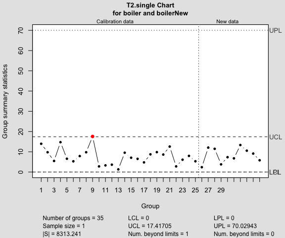

```r
summary(q2)
```

```
##
## Call:
## mqcc(data = boiler, type = "T2.single", pred.limits = TRUE, newdata = boilerNew,     confidence.level = 0.999)
##
## T2.single chart for boiler
##
## Summary of group statistics:
##      Min.   1st Qu.    Median      Mean   3rd Qu.      Max.
##  1.316342  5.305689  7.074224  7.680000  9.775744 17.575293
##
## Number of variables:  8
## Number of groups:  25
## Group sample size:  1
##
## Center:
##     t1     t2     t3     t4     t5     t6     t7     t8
## 525.00 513.56 538.92 521.68 503.80 512.44 478.72 477.24
##
## Covariance matrix:
##            t1        t2        t3         t4         t5         t6
## t1 54.0000000 0.9583333 20.583333 31.2916667 20.3333333 -2.2916667
## t2  0.9583333 4.8400000  2.963333  2.6866667  0.3250000  3.0766667
## t3 20.5833333 2.9633333 22.993333 10.0566667  4.9833333  2.0366667
## t4 31.2916667 2.6866667 10.056667 22.3100000 13.5583333 -2.2700000
## t5 20.3333333 0.3250000  4.983333 13.5583333 11.4166667 -1.6583333
## t6 -2.2916667 3.0766667  2.036667 -2.2700000 -1.6583333  4.5066667
## t7 20.3750000 0.7050000  6.476667 12.6983333 10.6500000 -0.7466667
## t8  0.2083333 3.4433333  2.770000  0.1633333 -0.2833333  3.7233333
##            t7         t8
## t1 20.3750000  0.2083333
## t2  0.7050000  3.4433333
## t3  6.4766667  2.7700000
## t4 12.6983333  0.1633333
## t5 10.6500000 -0.2833333
## t6 -0.7466667  3.7233333
## t7 11.6266667  0.5283333
## t8  0.5283333  3.8566667
## |S|:  8313.241
##
## Summary of group statistics in boilerNew:
##      Min.   1st Qu.    Median      Mean   3rd Qu.      Max.
##  2.387716  6.055542  8.214904  8.262216 11.238031 13.329123
##
## Number of groups:  10
## Group sample size:  1
##
## Control limits:
##  LCL      UCL
##    0 17.41705
##
## Prediction limits:
##  LPL      UPL
##    0 70.02943
```

Generate new “out of control” data:

```r
boilerNew = MASS::mvrnorm(10, mu = 1.01*q1$center, Sigma = q1$cov)
q3 = mqcc(boiler, type = "T2.single", confidence.level = 0.999,
          newdata = boilerNew, pred.limits = TRUE)
```

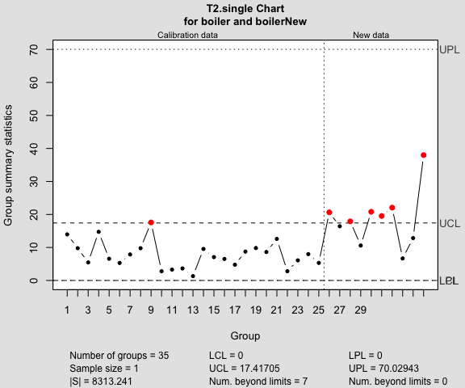

```r
summary(q3)
```

```
##
## Call:
## mqcc(data = boiler, type = "T2.single", pred.limits = TRUE, newdata = boilerNew,     confidence.level = 0.999)
##
## T2.single chart for boiler
##
## Summary of group statistics:
##      Min.   1st Qu.    Median      Mean   3rd Qu.      Max.
##  1.316342  5.305689  7.074224  7.680000  9.775744 17.575293
##
## Number of variables:  8
## Number of groups:  25
## Group sample size:  1
##
## Center:
##     t1     t2     t3     t4     t5     t6     t7     t8
## 525.00 513.56 538.92 521.68 503.80 512.44 478.72 477.24
##
## Covariance matrix:
##            t1        t2        t3         t4         t5         t6
## t1 54.0000000 0.9583333 20.583333 31.2916667 20.3333333 -2.2916667
## t2  0.9583333 4.8400000  2.963333  2.6866667  0.3250000  3.0766667
## t3 20.5833333 2.9633333 22.993333 10.0566667  4.9833333  2.0366667
## t4 31.2916667 2.6866667 10.056667 22.3100000 13.5583333 -2.2700000
## t5 20.3333333 0.3250000  4.983333 13.5583333 11.4166667 -1.6583333
## t6 -2.2916667 3.0766667  2.036667 -2.2700000 -1.6583333  4.5066667
## t7 20.3750000 0.7050000  6.476667 12.6983333 10.6500000 -0.7466667
## t8  0.2083333 3.4433333  2.770000  0.1633333 -0.2833333  3.7233333
##            t7         t8
## t1 20.3750000  0.2083333
## t2  0.7050000  3.4433333
## t3  6.4766667  2.7700000
## t4 12.6983333  0.1633333
## t5 10.6500000 -0.2833333
## t6 -0.7466667  3.7233333
## t7 11.6266667  0.5283333
## t8  0.5283333  3.8566667
## |S|:  8313.241
##
## Summary of group statistics in boilerNew:
##     Min.  1st Qu.   Median     Mean  3rd Qu.     Max.
##  6.66978 13.74057 18.72251 18.54601 20.76794 37.98010
##
## Number of groups:  10
## Group sample size:  1
##
## Control limits:
##  LCL      UCL
##    0 17.41705
##
## Prediction limits:
##  LPL      UPL
##    0 70.02943
```

Recompute by providing “robust” estimates for the means and the covariance matrix:

```r
rob = MASS::cov.rob(boiler)
q4 = mqcc(boiler, type = "T2.single", center = rob$center, cov = rob$cov)
```

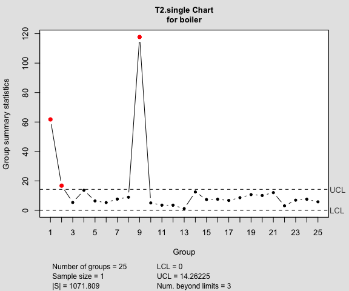

```r
summary(q4)
```

```
##
## Call:
## mqcc(data = boiler, type = "T2.single", center = rob$center,     cov = rob$cov)
##
## T2.single chart for boiler
##
## Summary of group statistics:
##      Min.   1st Qu.    Median      Mean   3rd Qu.      Max.
##   1.13929   5.35641   7.52501  14.21985  10.68735 117.73932
##
## Number of variables:  8
## Number of groups:  25
## Group sample size:  1
##
## Center:
##       t1       t2       t3       t4       t5       t6       t7       t8
## 525.4348 513.4348 539.9130 521.6087 503.8261 512.4783 478.8696 477.2609
##
## Covariance matrix:
##            t1        t2        t3         t4         t5         t6
## t1 41.0750988 2.9387352 16.221344 26.8596838 16.7154150 -2.7173913
## t2  2.9387352 4.9841897  4.903162  3.4051383  0.8063241  3.4189723
## t3 16.2213439 4.9031621 12.173913 11.6007905  4.8932806  1.7252964
## t4 26.8596838 3.4051383 11.600791 20.4308300 12.1561265 -2.4407115
## t5 16.7154150 0.8063241  4.893281 12.1561265 10.6047431 -1.8221344
## t6 -2.7173913 3.4189723  1.725296 -2.4407115 -1.8221344  4.8972332
## t7 15.4683794 1.4683794  4.897233 11.0375494  9.5217391 -0.8893281
## t8  0.1086957 3.7905138  2.750988  0.1976285 -0.3162055  4.0513834
##            t7         t8
## t1 15.4683794  0.1086957
## t2  1.4683794  3.7905138
## t3  4.8972332  2.7509881
## t4 11.0375494  0.1976285
## t5  9.5217391 -0.3162055
## t6 -0.8893281  4.0513834
## t7 10.1185771  0.5355731
## t8  0.5355731  4.2015810
## |S|:  1071.809
##
## Control limits:
##  LCL      UCL
##    0 14.26225
```

## Pareto chart

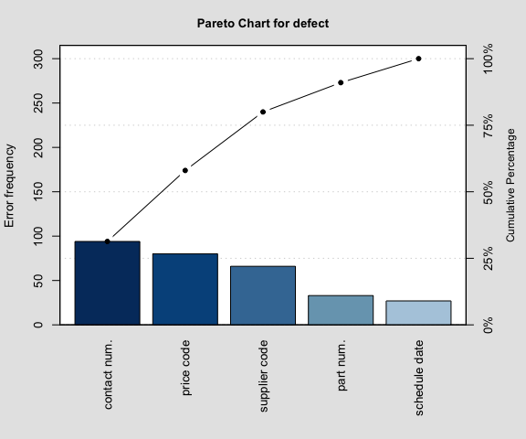

```
##
## Pareto chart analysis for defect
##                 Frequency Cum.Freq. Percentage Cum.Percent.
##   contact num.   94.00000  94.00000   31.33333     31.33333
##   price code     80.00000 174.00000   26.66667     58.00000
##   supplier code  66.00000 240.00000   22.00000     80.00000
##   part num.      33.00000 273.00000   11.00000     91.00000
##   schedule date  27.00000 300.00000    9.00000    100.00000
```

```r
defect = c(80, 27, 66, 94, 33)
names(defect) = c("price code", "schedule date", "supplier code", "contact num.", "part num.")
pareto.chart(defect, ylab = "Error frequency")
```

## Cause and effect diagram

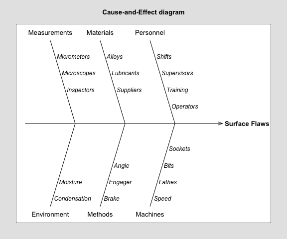

```r
cause.and.effect(cause = list(Measurements = c("Micrometers", "Microscopes", "Inspectors"),
                              Materials    = c("Alloys", "Lubricants", "Suppliers"),
                              Personnel    = c("Shifts", "Supervisors", "Training", "Operators"),
                              Environment  = c("Condensation", "Moisture"),
                              Methods      = c("Brake", "Engager", "Angle"),
                              Machines     = c("Speed", "Lathes", "Bits", "Sockets")),
                 effect = "Surface Flaws")
```

## Process variation examples

In the following simulated data are used to describe some models for process variation. For further details see Wetherill, G.B. and Brown, D.W. (1991) *Statistical Process Control*, New York, Chapman and Hall, Chapter 3.

### Simple random variation

$x_{ij} = \mu + \sigma_W \epsilon_{ij}$

```r
mu = 100
sigma_W = 10
epsilon = rnorm(500)
x = matrix(mu + sigma_W*epsilon, ncol=10, byrow=TRUE)
q = qcc(x, type="xbar")
```

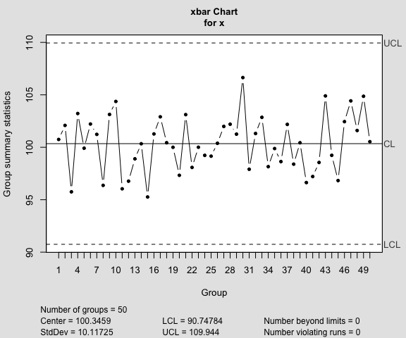

```r
q = qcc(x, type="R")
```

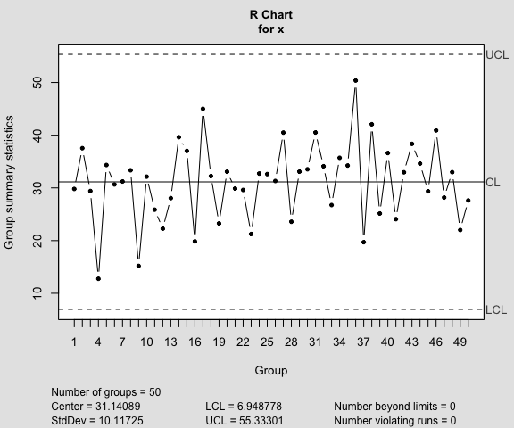

```r
q = qcc(x, type="S")
```

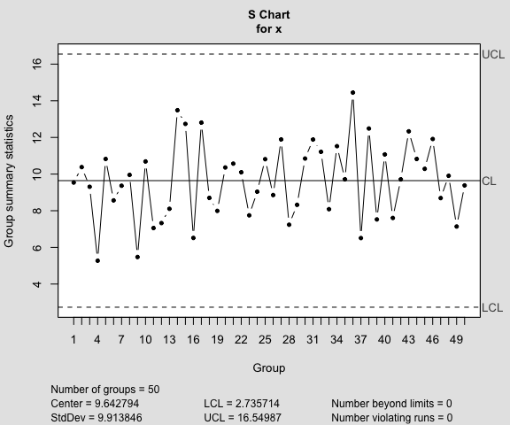

### Between and within sample extra variation

$x_{ij} = \mu + \sigma_B u_i + \sigma_W \epsilon_{ij}$

```r
mu = 100
sigma_W = 10
sigma_B = 5
epsilon = rnorm(500)
u = as.vector(sapply(rnorm(50), rep, 10))
x = mu + sigma_B*u + sigma_W*epsilon
x = matrix(x, ncol=10, byrow=TRUE)
q = qcc(x, type="xbar")
```

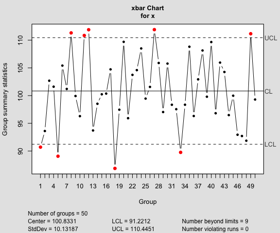

```r
q = qcc(x, type="R")
```

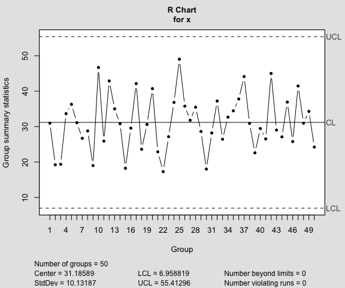

```r
q = qcc(x, type="S")
```

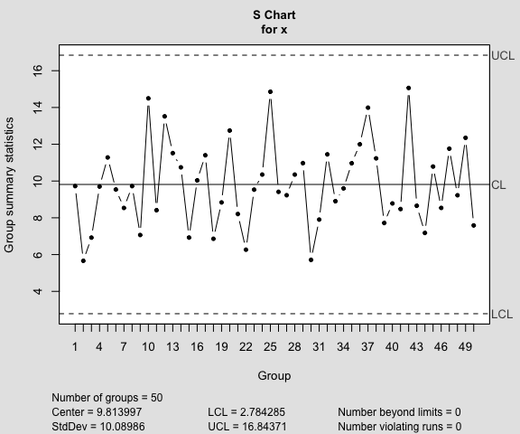

### Autocorrelation

$x_{ij} = \mu + W_i + \sigma_W \epsilon_{ij}$  
where $W_i = \rho W_{i-1} + \sigma_B u_i = \sigma_B u_i + \rho \sigma_B u_{i-1} + \rho^2 \sigma_B u_{i-2} + \ldots$,  
and $W_0 = 0$.

```r
mu = 100
rho = 0.8
sigma_W = 10
sigma_B = 5
epsilon = rnorm(500)
u = rnorm(500)
W = rep(0,100)
for(i in 2:length(W))
    W[i] = rho*W[i-1] + sigma_B*u[i]
x = mu + sigma_B*u + sigma_W*epsilon
x = matrix(x, ncol=10, byrow=TRUE)
q = qcc(x, type="xbar")
```

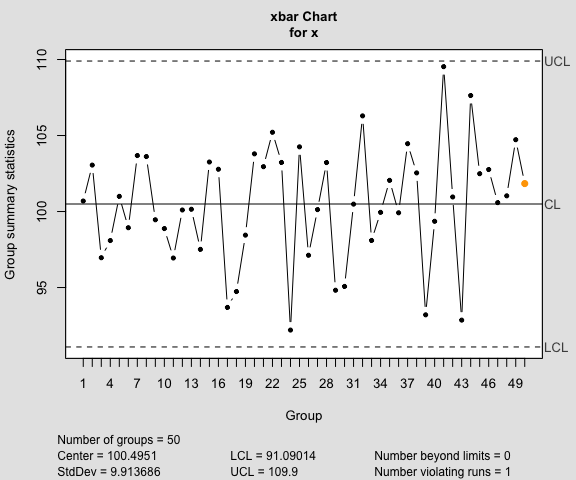

```r
q = qcc(x, type="R")
```

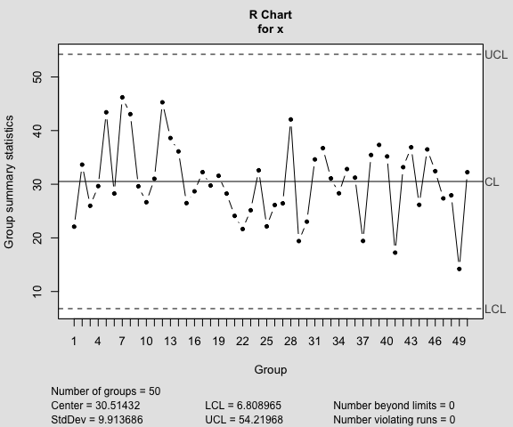

```r
q = qcc(x, type="S")
```

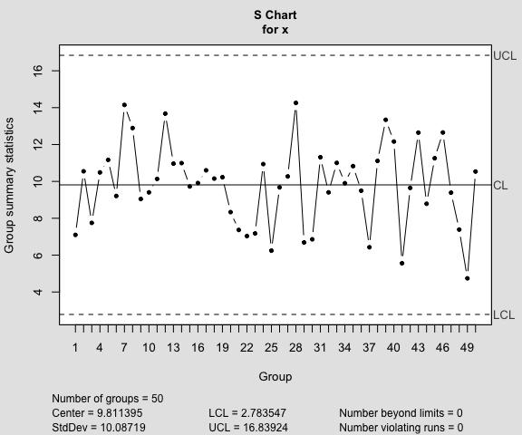

### Recurring cycles

Assume we have 3 working turns of 8 hours each for each working day, so $8 \times 3 = 24$ points in time, and at each point we sample 5 units.

$x_{ij} = \mu + W_i + \sigma_W \epsilon_{ij}$  
where $W_i$ ($i=1,\ldots,8$) is the cycle.

```r
mu = 100
sigma_W = 10
epsilon = rnorm(120, sd=0.3)
W = c(-4, 0, 1, 2, 4, 2, 0, -2) # assumed workers cycle
W = rep(rep(W, rep(5,8)), 3)
x = mu + W + sigma_W*epsilon
x = matrix(x, ncol=5, byrow=TRUE)
q = qcc(x, type="xbar")
```

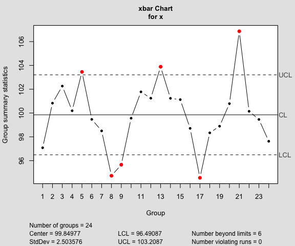

```r
q = qcc(x, type="R")
```

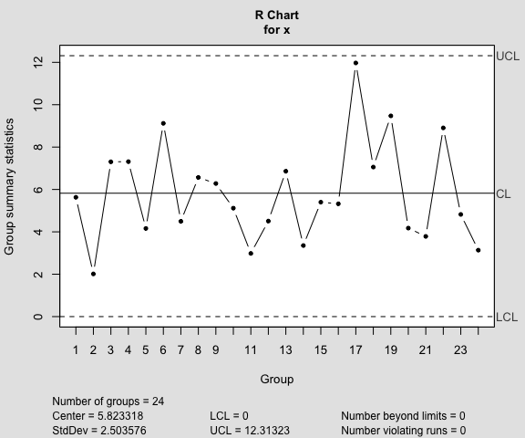

```r
q = qcc(x, type="S")
```

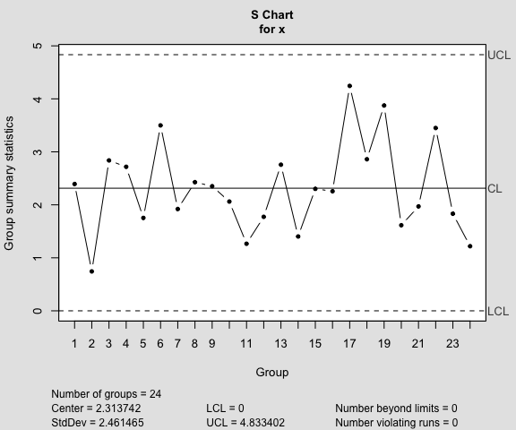

### Trends

$x_{ij} = \mu + W_i + \sigma_W \epsilon_{ij}$  
where $W_i = 0.2 i$

```r
mu = 100
sigma_W = 10
epsilon = rnorm(500)
W = rep(0.2*1:100, rep(5,100))
x = mu + W + sigma_W*epsilon
x = matrix(x, ncol=10, byrow=TRUE)
q = qcc(x, type="xbar")
```

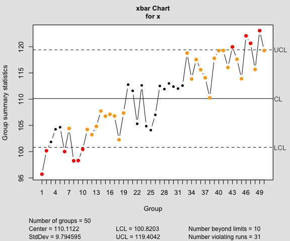

```r
q = qcc(x, type="R")
```

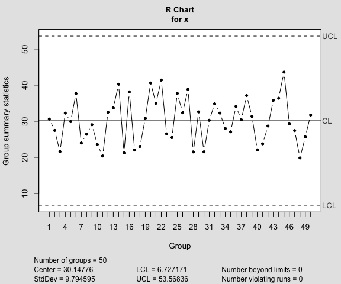

```r
q = qcc(x, type="S")
```

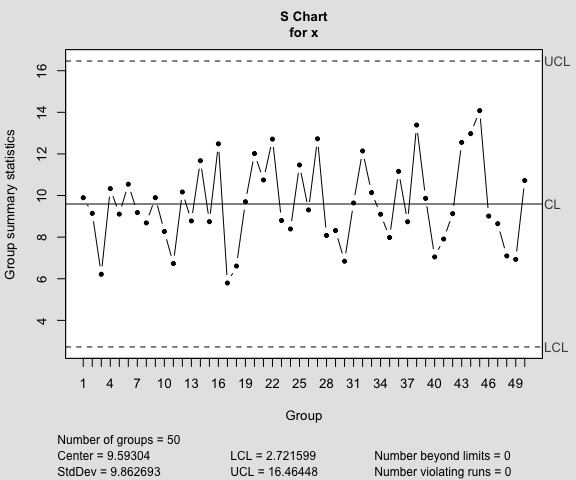

### Mixture

$x_{ij} = \mu_1 p + \mu_2 (1-p) + \sigma_W \epsilon_{ij}$  
where $p = \Pr(\text{Process #1})$.

```r
mu1 = 90
mu2 = 110
sigma_W = 10
epsilon = rnorm(500)
p = rbinom(50, 1, 0.5)
mu = mu1*p + mu2*(1-p)
x = rep(mu, rep(10, length(mu))) + sigma_W*epsilon
x = matrix(x, ncol=10, byrow=TRUE)
q = qcc(x, type="xbar")
```

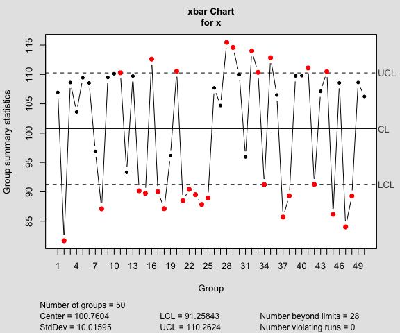

```r
q = qcc(x, type="R")
```

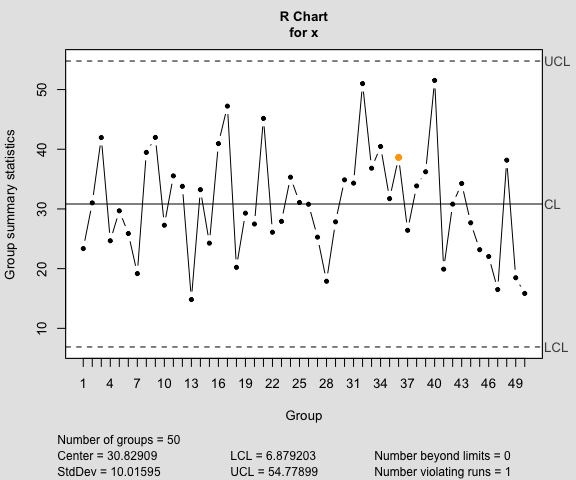

```r
q = qcc(x, type="S")
```

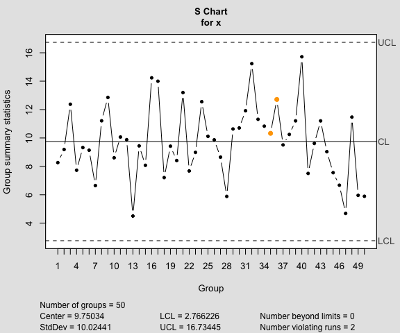

### Sudden jumps

$x_{ij} = \mu_i + \sigma_W \epsilon_{ij}$  
where $\mu_i$ is the mean of the process for state $i$ ($i=1,\ldots,k)$.

```r
mu = rep(c(95,110,100,90), c(20,35,25,20))
sigma_W = 10
epsilon = rnorm(500)
x = rep(mu, rep(5, length(mu))) + sigma_W*epsilon
x = matrix(x, ncol=10, byrow=TRUE)
q = qcc(x, type="xbar")
```

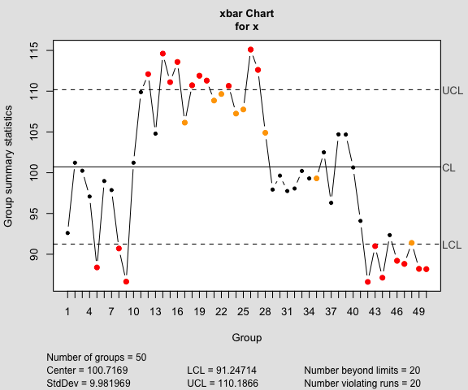

```r
q = qcc(x, type="R")
```

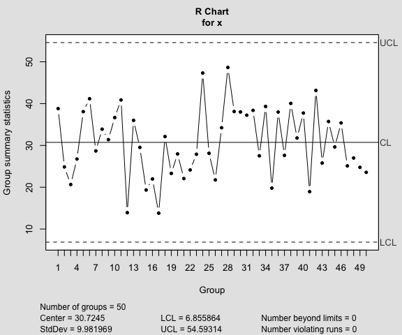

```r
q = qcc(x, type="S")
```

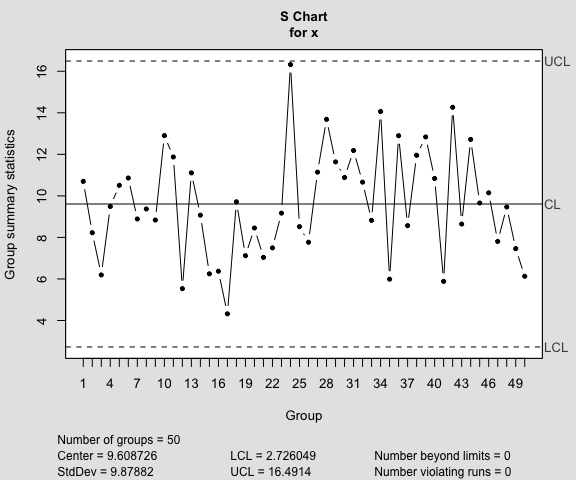